# Ejercicio 1 y 2. Materiales

Pag 26. Everest. TIN II

Aurelio Gallardo Rodríguez

6 de junio de 2017

# Enunciado Ejercicio 1

1. Una probeta cilíndrica de 10mm de diámetro y 100mm de longitud alcanza los siguientes datos:
1. Límite de proporcionalidad: $F_{P}=3kN$ a los $\Delta L_{P}=0.2mm$
2. Límite de elasticidad: $F_{E}=3.2kN$ a los $\Delta L_{E}=0.22mm$
3. Resistencia a la tracción: $F_{R}=16kN$ a los $\Delta L_{R}=4mm$
4. Resistencia a la rotura: $F_{U}=14kN$ a los $\Delta L_{U}=4.5mm$

Dibuja la gráfica tensión - deformación , y calcula el módulo de Young del material.

# Cálculos del problema

Mostrando los datos pasados a tensión - alargamiento:

1. Superficie $S_{0}=78.5398163\cdot mm2$
2. Lím. de Proporcionalidad –> $\sigma_{p}=F_{p}/S_{0}=3.8197186\times 10^{7}\cdot N m-2$
3. $\epsilon_{p}={(L_{p}-L_{0})} / L_{0} = 0.002$
4. Lím. Elástico –> $\sigma_{e}=F_{e}/S_{0}=4.0743665\times 10^{7}\cdot N m-2$
5. $\epsilon_{e}={(L_{e}-L_{0})} / L_{0} =0.0022$

# Y seguimos con los cálculos

6. Lím. Resistencia a la tracción –> $\sigma_{R}=F_{R}/S_{0}=2.0371833\times 10^{8}\cdot N m-2$
7. $\epsilon_{R}={(L_{R}-L_{0})} / L_{0}=0.04$
8. Lím. Resistencia a la tracción –> $\sigma_{U}=F_{U}/S_{0}=1.7825354\times 10^{8}\cdot N m-2$
9. $\epsilon_{U}={(L_{U}-L_{0})} / L_{0} =0.045$

# Gráfica y módulo de Young

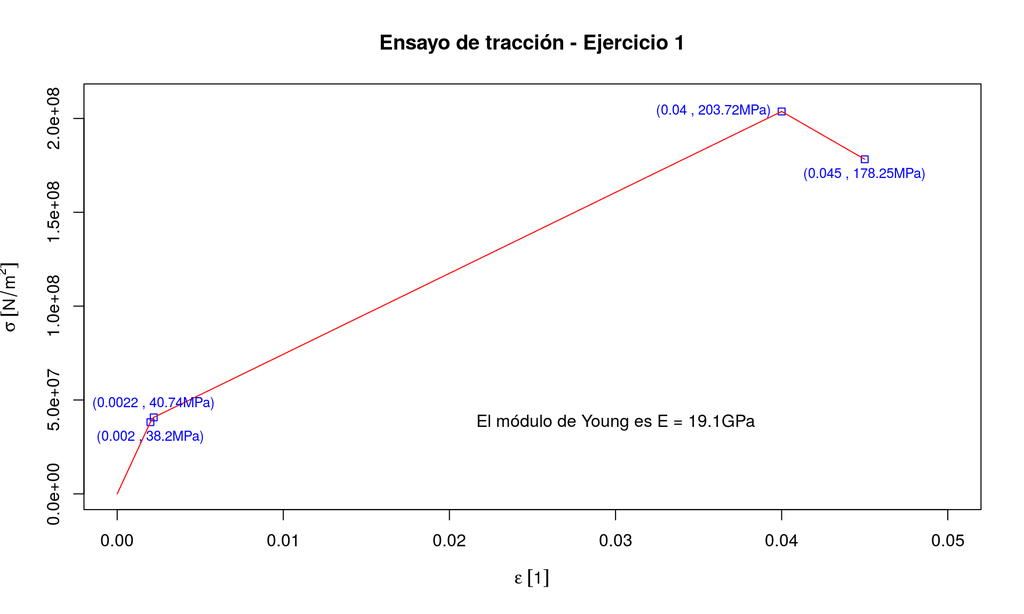

# Enunciado Ejercicio 2

Calcula el trabajo realizado para deformar y romper la probeta, según el ejercicio anterior. Considera que entre los puntos consecutivos las líneas son rectas.

# Ejercicio 2: Trabajo de deformación

```r
# Trabajo bajo la curva
W1=Fp*Lp/2
W2=Fp*(Le-Lp)
W3=(Fe-Fp)*(Le-Lp)/2
W4=Fe*(LR-Le)
W5=(FR-Fe)*(LR-Le)/2
W6=FU*(LU-LR)
W7=(FR-FU)*(LU-LR)/2
W=W1+W2+W3+W4+W5+W6+W7
units(W)=with(ud_units,J)
W
```

```
## 44.15 J
```

El trabajo realizado es, entonces, $W = 44.15 J$